# Sosiaalisen median aktiivikäyttö ja syntyvyys

Antti J. Tanskanen, Elinkeinoelämän keskusliitto EK

1.3.2023

## Aineisto

Työllisyyttä (Tilastokeskus) kuvataan 10-vuotisikäluokittaisilla työllisyysasteilla sukupuolittain, 10-vuotisikäluokkakohtaisista työttömyysasteista sukupuolittain (suhteutettu ikäluokan kokoon, ), ja työsuhteiden tyyppitiedoilla (jatkuva/määräaikainen; kokoaikainen/osa-aikainen) vuosilta 1997-2017. Kaupungistumista kuvaa sisemmässä kaupungissa, ulommassa kaupungissa ja kehyskaupungissa asuvien osuudet väestöstä (Tilastokeskus)

Verrattuna aiempiin harjoitelmiin, mukaan on otettu myös sosiaalisen median aktiivikäyttäjien osuus Tilastokeskuksen Viestintä- ja tietotekniikan käyttö-tutkimuksesta (“Seuraa jotain yhteisöpalvelua yleensä jatkuvasti kirjautuneena tai useasti päivässä”).

Aineiston perusteella ei voi tehdä kausaalisia päätelmiä, ainostaan assosiatiivisuutta koskevia. Tämä tietenkin rajoittaa tulkintamahdollisuuksia.

Tarkoituksena on avoimen, toistettavan tutkimuksen hengessä näyttää täsmällisesti mitä on tehty. Tästä syystä alkuperäinen aineisto (myös tämä työkirja koodeineen, Rmd-muotoisena; data Rdata-muodossa) on kokonaisuudessaan saatavissa osoitteesta https://github.com/ajtanskanen/Syntyvyyden-tekij-t

# Hedelmällisyysluvun muutoksia selittävä malli

Synnytysikäisten naisten lukumäärää pystytään lyhyellä aikavälillä ennustamaan melko hyvin, eikä siihen vaikuta juurikaan muut tekijät, kuten vaikkapa työllisyys tai taloudellinen tilanne. Jos jokin vaikuttaa syntyvyyteen, vaikutuksen pitäisi näkyä hedelmällisyysluvussa.

```
##                               P(B != 0 | Y) model 1 model 2 model 3
## Intercept                             1.000   1.000   1.000   1.000
## synnyttajien_keskiika                 0.132   0.000   0.000   0.000
## avioituvuus_naiset_25_29_lag1         0.135   0.000   0.000   0.000
## avioituvuus_naiset_30_34_lag1         0.922   1.000   1.000   1.000
## kehyskaupunki                         0.242   0.000   0.000   1.000
## sisempikaupunki                       0.976   1.000   1.000   1.000
## ulompikaupunki                        0.297   0.000   1.000   0.000
## some_25_34_lag1                       0.251   0.000   0.000   0.000
## some_35_44_lag1                       0.114   0.000   0.000   0.000
## dummy2021                             0.974   1.000   1.000   1.000
## BF                                       NA   1.000   0.263   0.226
## PostProbs                                NA   0.318   0.096   0.071
## R2                                       NA   0.972   0.975   0.975
## dim                                      NA   4.000   5.000   5.000
## logmarg                                  NA  45.117  43.782  43.629
```

```
##                               P(B != 0 | Y) model 1 model 2 model 3
## Intercept                             1.000   1.000   1.000   1.000
## synnyttajien_keskiika                 0.236   0.000   0.000   0.000
## avioituvuus_naiset_25_29_lag1         0.146   0.000   0.000   0.000
## avioituvuus_naiset_30_34_lag1         0.821   1.000   0.000   1.000
## kehyskaupunki                         0.410   0.000   1.000   1.000
## sisempikaupunki                       0.931   1.000   1.000   1.000
## ulompikaupunki                        0.282   0.000   0.000   0.000
## some_25_34_lag1                       0.408   0.000   1.000   1.000
## some_35_44_lag1                       0.169   0.000   0.000   0.000
## dummy2021                             0.983   1.000   1.000   1.000
## BF                                       NA   1.000   0.428   0.392
## PostProbs                                NA   0.178   0.089   0.080
## R2                                       NA   0.966   0.970   0.975
## dim                                      NA   4.000   5.000   6.000
## logmarg                                  NA  40.585  39.737  39.647
```

```
##                               P(B != 0 | Y) model 1 model 2 model 3
## Intercept                             1.000   1.000   1.000   1.000
## synnyttajien_keskiika                 0.200   0.000   0.000   0.000
## avioituvuus_naiset_25_29_lag1         0.132   0.000   0.000   0.000
## avioituvuus_naiset_30_34_lag1         0.830   1.000   0.000   1.000
## kehyskaupunki                         0.387   0.000   1.000   1.000
## sisempikaupunki                       0.935   1.000   1.000   1.000
## ulompikaupunki                        0.236   0.000   0.000   0.000
## some_25_34_lag1                       0.381   0.000   1.000   1.000
## some_35_44_lag1                       0.136   0.000   0.000   0.000
## BF                                       NA   1.000   0.399   0.348
## PostProbs                                NA   0.251   0.097   0.081
## R2                                       NA   0.962   0.967   0.973
## dim                                      NA   3.000   4.000   5.000
## logmarg                                  NA  40.206  39.288  39.150
```

```
##                               P(B != 0 | Y) model 1 model 2 model 3
## Intercept                             1.000   1.000   1.000   1.000
## synnyttajien_keskiika                 0.188   0.000   0.000   1.000
## avioituvuus_naiset_25_29_lag1         0.153   0.000   0.000   0.000
## avioituvuus_naiset_30_34_lag1         0.467   0.000   1.000   1.000
## kehyskaupunki                         0.809   1.000   1.000   0.000
## sisempikaupunki                       0.997   1.000   1.000   1.000
## ulompikaupunki                        0.384   0.000   0.000   1.000
## some_25_34_lag1                       0.150   0.000   0.000   0.000
## some_35_44_lag1                       0.969   1.000   1.000   1.000
## BF                                       NA   1.000   0.612   0.195
## PostProbs                                NA   0.270   0.183   0.076
## R2                                       NA   0.974   0.979   0.981
## dim                                      NA   4.000   5.000   6.000
## logmarg                                  NA  41.022  40.531  39.387
```

```
##                               P(B != 0 | Y) model 1 model 2 model 3
## Intercept                             1.000   1.000   1.000   1.000
## synnyttajien_keskiika                 0.209   0.000   0.000   1.000
## avioituvuus_naiset_25_29_lag1         0.244   0.000   0.000   0.000
## avioituvuus_naiset_30_34_lag1         0.544   1.000   0.000   1.000
## kehyskaupunki                         0.759   1.000   1.000   0.000
## sisempikaupunki                       0.987   1.000   1.000   1.000
## ulompikaupunki                        0.463   0.000   0.000   1.000
## some_25_34_lag1                       0.309   0.000   0.000   0.000
## some_35_44_lag1                       0.753   1.000   1.000   1.000
## BF                                       NA   0.897   1.000   0.385
## PostProbs                                NA   0.160   0.108   0.062
## R2                                       NA   0.969   0.962   0.974
## dim                                      NA   5.000   4.000   6.000
## logmarg                                  NA  34.499  34.608  33.652
```

```
##                               P(B != 0 | Y) model 1 model 2 model 3
## Intercept                             1.000   1.000   1.000   1.000
## synnyttajien_keskiika                 0.320   0.000   0.000   1.000
## avioituvuus_naiset_25_29_lag1         0.321   0.000   0.000   0.000
## avioituvuus_naiset_30_34_lag1         0.549   0.000   1.000   1.000
## kehyskaupunki                         0.575   1.000   1.000   0.000
## sisempikaupunki                       0.979   1.000   1.000   1.000
## ulompikaupunki                        0.587   0.000   0.000   1.000
## some_25_34_lag1                       0.310   0.000   0.000   0.000
## some_35_44_lag1                       0.705   1.000   1.000   1.000
## BF                                       NA   0.599   0.760   1.000
## PostProbs                                NA   0.096   0.088   0.078
## R2                                       NA   0.942   0.954   0.964
## dim                                      NA   4.000   5.000   6.000
## logmarg                                  NA  28.108  28.346  28.621
```

```
##
##  Marginal Posterior Summaries of Coefficients:
##
##  Using  BMA
##
##  Based on the top  129 models
##                                post mean   post SD     post p(B != 0)
## Intercept                       1.708e+00   4.912e-03   1.000e+00
## synnyttajien_keskiika          -1.070e-02   4.219e-02   1.324e-01
## avioituvuus_naiset_25_29_lag1  -4.172e-05   1.798e-03   1.353e-01
## avioituvuus_naiset_30_34_lag1   7.704e-03   2.975e-03   9.217e-01
## kehyskaupunki                   3.500e-02   8.082e-02   2.424e-01
## sisempikaupunki                -8.932e-02   2.396e-02   9.758e-01
## ulompikaupunki                  1.940e-02   3.770e-02   2.971e-01
## some_25_34_lag1                -4.196e-04   9.260e-04   2.509e-01
## some_35_44_lag1                -8.842e-05   4.734e-04   1.136e-01
## dummy2021                       1.288e-01   4.039e-02   9.735e-01
```

```
##
##  Marginal Posterior Summaries of Coefficients:
##
##  Using  BMA
##
##  Based on the top  153 models
##                                post mean   post SD     post p(B != 0)
## Intercept                       1.7206250   0.0049539   1.0000000
## synnyttajien_keskiika          -0.0291627   0.0723865   0.2361328
## avioituvuus_naiset_25_29_lag1  -0.0001355   0.0017545   0.1456055
## avioituvuus_naiset_30_34_lag1   0.0063800   0.0037406   0.8211914
## kehyskaupunki                   0.0793103   0.1199527   0.4102539
## sisempikaupunki                -0.0865108   0.0314813   0.9313477
## ulompikaupunki                  0.0198174   0.0397268   0.2815430
## some_25_34_lag1                -0.0009321   0.0013537   0.4082031
## some_35_44_lag1                -0.0001402   0.0006587   0.1686523
## dummy2021                       0.1511388   0.0464532   0.9833984
```

```
##
##  Marginal Posterior Summaries of Coefficients:
##
##  Using  BMA
##
##  Based on the top  113 models
##                                post mean   post SD     post p(B != 0)
## Intercept                       1.729e+00   5.042e-03   1.000e+00
## synnyttajien_keskiika          -2.543e-02   6.778e-02   2.004e-01
## avioituvuus_naiset_25_29_lag1  -7.334e-05   1.736e-03   1.322e-01
## avioituvuus_naiset_30_34_lag1   6.615e-03   3.728e-03   8.303e-01
## kehyskaupunki                   7.498e-02   1.178e-01   3.865e-01
## sisempikaupunki                -8.586e-02   3.016e-02   9.348e-01
## ulompikaupunki                  1.703e-02   3.843e-02   2.357e-01
## some_25_34_lag1                -8.568e-04   1.306e-03   3.807e-01
## some_35_44_lag1                -1.350e-04   5.873e-04   1.359e-01
```

```
##
##  Marginal Posterior Summaries of Coefficients:
##
##  Using  BMA
##
##  Based on the top  75 models
##                                post mean   post SD     post p(B != 0)
## Intercept                       1.7410000   0.0038403   1.0000000
## synnyttajien_keskiika          -0.0159398   0.0502720   0.1882813
## avioituvuus_naiset_25_29_lag1   0.0003799   0.0013866   0.1533203
## avioituvuus_naiset_30_34_lag1   0.0017488   0.0022165   0.4673828
## kehyskaupunki                   0.1934003   0.1123613   0.8091797
## sisempikaupunki                -0.0941864   0.0180384   0.9974609
## ulompikaupunki                  0.0312977   0.0478453   0.3843750
## some_25_34_lag1                 0.0001822   0.0010965   0.1500000
## some_35_44_lag1                -0.0046745   0.0016177   0.9693359
```

```
##
##  Marginal Posterior Summaries of Coefficients:
##
##  Using  BMA
##
##  Based on the top  91 models
##                                post mean   post SD     post p(B != 0)
## Intercept                       1.7544828   0.0039261   1.0000000
## synnyttajien_keskiika          -0.0180157   0.0544469   0.2093750
## avioituvuus_naiset_25_29_lag1   0.0007196   0.0018847   0.2443359
## avioituvuus_naiset_30_34_lag1   0.0021143   0.0024274   0.5443359
## kehyskaupunki                   0.1649317   0.1128406   0.7585937
## sisempikaupunki                -0.0917236   0.0209157   0.9867187
## ulompikaupunki                  0.0395362   0.0521154   0.4632812
## some_25_34_lag1                -0.0005248   0.0016727   0.3087891
## some_35_44_lag1                -0.0032050   0.0023536   0.7531250
```

```
##
##  Marginal Posterior Summaries of Coefficients:
##
##  Using  BMA
##
##  Based on the top  111 models
##                                post mean   post SD     post p(B != 0)
## Intercept                       1.7660714   0.0039762   1.0000000
## synnyttajien_keskiika          -0.0330430   0.0638470   0.3203125
## avioituvuus_naiset_25_29_lag1   0.0011983   0.0023647   0.3214844
## avioituvuus_naiset_30_34_lag1   0.0024609   0.0027120   0.5494141
## kehyskaupunki                   0.1156552   0.1214481   0.5748047
## sisempikaupunki                -0.0850588   0.0241874   0.9787109
## ulompikaupunki                  0.0569347   0.0581394   0.5869141
## some_25_34_lag1                -0.0004713   0.0014972   0.3103516
## some_35_44_lag1                -0.0026465   0.0022507   0.7050781
```

Aggregaattikertoimet kaikissa mallissa todennäköisyyksillä painotettuna ovat

```
##
##  Marginal Posterior Summaries of Coefficients:
##
##  Using  BMA
##
##  Based on the top  129 models
##                                post mean   post SD     post p(B != 0)
## Intercept                       1.708e+00   4.912e-03   1.000e+00
## synnyttajien_keskiika          -1.070e-02   4.219e-02   1.324e-01
## avioituvuus_naiset_25_29_lag1  -4.172e-05   1.798e-03   1.353e-01
## avioituvuus_naiset_30_34_lag1   7.704e-03   2.975e-03   9.217e-01
## kehyskaupunki                   3.500e-02   8.082e-02   2.424e-01
## sisempikaupunki                -8.932e-02   2.396e-02   9.758e-01
## ulompikaupunki                  1.940e-02   3.770e-02   2.971e-01
## some_25_34_lag1                -4.196e-04   9.260e-04   2.509e-01
## some_35_44_lag1                -8.842e-05   4.734e-04   1.136e-01
## dummy2021                       1.288e-01   4.039e-02   9.735e-01
```

Tarkastetaan vielä, millaisia residuaaleja jää selittämättä mallilla

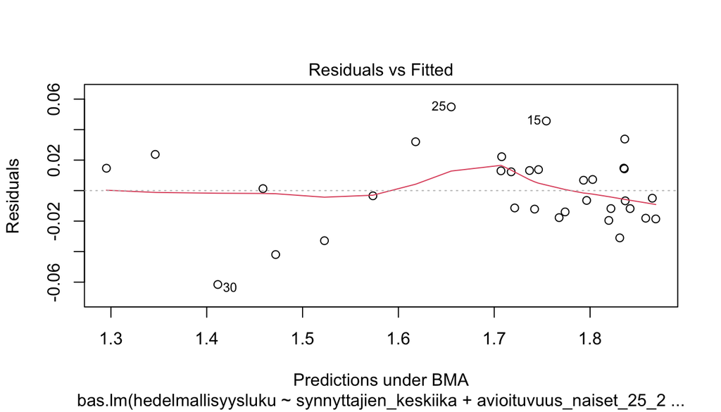

Ja lopuksi verrataan mallin sovitetta

```
##  [1] 1990 1991 1992 1993 1994 1995 1996 1997 1998 1999 2000 2001 2002 2003 2004
## [16] 2005 2006 2007 2008 2009 2010 2011 2012 2013 2014 2015 2016 2017 2018 2019
## [31] 2020 2021 2022
```

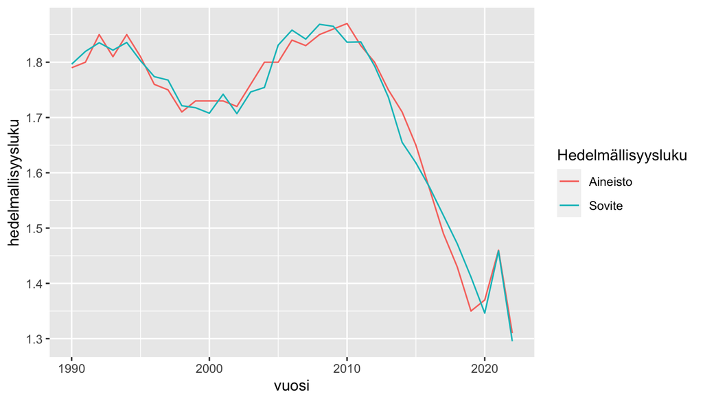

# Ennuste

Pyritään sitten arvioimaan miten hedelmällisyysluku kehittyy, mikäli 10 viime vuoden trendi jatkuisi näiden neljän tekijän osalta. Jatketaan trendiä lineaarisesti avioituvuudelle, kaupungistumiselle ja aktiivisten somen käyttäjien osuudelle. Muut tekijät pidetään vakiona.

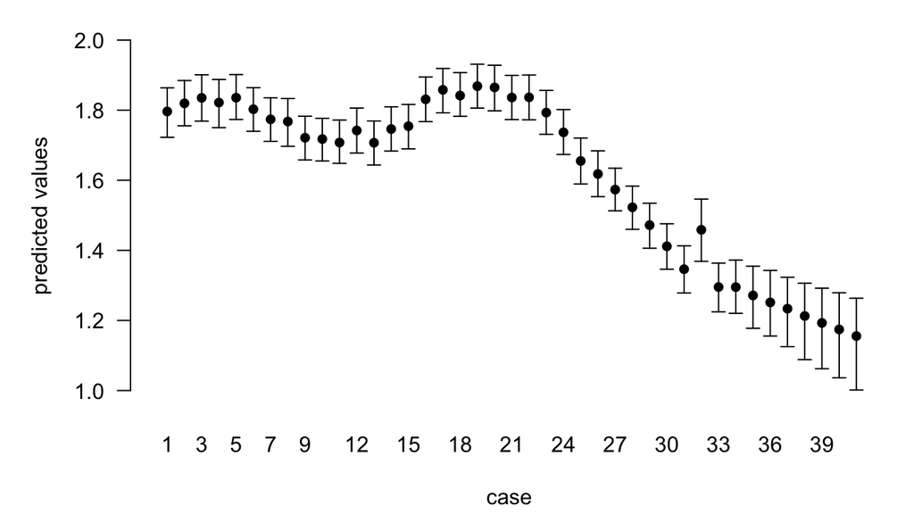

```
## # A tibble: 41 × 20
##    vuosi alypuhelin some_25_34 some_35_44 avioituvuus_25_29 avioituvuus_30_34
##    <dbl>      <dbl>      <dbl>      <dbl>             <dbl>             <dbl>
##  1  1990          0          0          0              87.5              51.4
##  2  1991          0          0          0              86                50.5
##  3  1992          0          0          0              81.1              49.5
##  4  1993          0          0          0              84.8              53.6
##  5  1994          0          0          0              84.1              54.2
##  6  1995          0          0          0              78.5              52.6
##  7  1996          0          0          0              78.5              55.4
##  8  1997          0          0          0              75.5              51.1
##  9  1998          0          0          0              74.8              52.7
## 10  1999          0          0          0              74.4              53
## # ℹ 31 more rows
## # ℹ 14 more variables: synnyttajien_keskiika <dbl>, sisempikaupunki <dbl>,
## #   ulompikaupunki <dbl>, kehyskaupunki <dbl>, maaseudulla <dbl>,
## #   avioituvuus_naiset_25_29_lag1 <dbl>, avioituvuus_naiset_30_34_lag1 <dbl>,
## #   alypuhelin_lag1 <dbl>, some_25_34_lag1 <dbl>, some_35_44_lag1 <dbl>,
## #   dummy2021 <dbl>, tfr_tk <dbl>, hedelmallisyysluku <dbl>,
## #   hedelmallisyysluku_lag1 <dbl>
```

```
## [1] 0.1892529
```

```
## [1] 0.03880606
```

```
## [1] 0.03994947
```

```
## [1] 0.0863624
```

```
## [1] 0.2157976
```

```
## [1] 0.07678426
```

```
## [1] 0.0693312
```

```
## [1] 0.1080895
```

```
## [1] 0.05948629
```

```
## [1] 0.09166667
```

```
## [1] 0.05076317
```

```
## [1] 0.1516667
```

```
## [1] -0.08833333
```

```
## [1] -0.01793217
```

```
## [1] 0.1516667
```

```
##  [1]       NA       NA       NA       NA       NA       NA       NA       NA
##  [9]       NA       NA       NA       NA       NA       NA       NA       NA
## [17]       NA       NA       NA       NA       NA       NA       NA       NA
## [25]       NA       NA       NA       NA       NA       NA       NA       NA
## [33] 1.295325 1.295143 1.271364 1.251499 1.233518 1.212708 1.192858 1.174359
## [41] 1.155480
```

ONESTEP

```
## [1] -0.06024626
```

```
##  [1]   NA   NA   NA   NA   NA   NA   NA   NA   NA   NA   NA   NA   NA   NA   NA
## [16]   NA   NA   NA   NA   NA   NA   NA   NA   NA   NA   NA   NA 1.49 1.41 1.35
## [31] 1.37 1.46 1.31 1.27   NA   NA   NA   NA   NA   NA   NA
```

```
## [1] 1.41
```

```
## [1] 1.470246
```

```
## [1] -0.1086027
```

```
## [1] -0.04057985
```

2018

```
## [1] -0.03509823
```

```
## [1] 0.03090752
```

```
## [1] 0.1606067
```

2019

```
## [1] 0.1607182
```

```
## [1] 1.37
```

```
## [1] 1.209282
```

```
## [1] 0.3471483
```

```
## [1] 0.254382
```

2020

```
## [1] 0.1645343
```

```
## [1] 1.46
```

```
## [1] 1.295466
```

```
## [1] 0.06842791
```

```
## [1] 0.07452195
```

2021

```
## [1] 0.01988064
```

```
## [1] 1.31
```

```
## [1] 1.290119
```

```
## [1] -0.04085826
```

2022

```
## [1] -0.02514251
```

```
## [1] 1.27
```

```
## [1] 1.295143
```

datat

```
##  [1] 1990 1991 1992 1993 1994 1995 1996 1997 1998 1999 2000 2001 2002 2003 2004
## [16] 2005 2006 2007 2008 2009 2010 2011 2012 2013 2014 2015 2016 2017 2018 2019
## [31] 2020 2021 2022 2023 2024 2025 2026 2027 2028 2029 2030
```

```
##  [1] 1.796437 1.819547 1.835250 1.821769 1.835740 1.802705 1.773966 1.767706
##  [9] 1.721356 1.717682 1.707775 1.742115 1.707030 1.746221 1.754349 1.830985
## [17] 1.858085 1.841783 1.868563 1.864969 1.836198 1.836692 1.793189 1.736826
## [25] 1.655118 1.617970 1.573409 1.522824 1.471922 1.411549 1.346258 1.458688
## [33] 1.295325       NA       NA       NA       NA       NA       NA       NA
## [41]       NA
```

```
##  [1]  NaN  NaN  NaN  NaN  NaN  NaN  NaN  NaN  NaN  NaN  NaN  NaN  NaN  NaN  NaN
## [16]  NaN  NaN  NaN  NaN  NaN  NaN  NaN  NaN  NaN  NaN  NaN  NaN  NaN 1.45 1.45
## [31] 1.45 1.45 1.45 1.45 1.45 1.45 1.45 1.45 1.45 1.45 1.45
```

```
##  [1] 1.79 1.80 1.85 1.81 1.85 1.81 1.76 1.75 1.71 1.73 1.73 1.73 1.72 1.76 1.80
## [16] 1.80 1.84 1.83 1.85 1.86 1.87 1.83 1.80 1.75 1.71 1.65 1.57 1.49   NA 1.35
## [31] 1.37 1.46 1.31  NaN  NaN  NaN  NaN  NaN  NaN  NaN  NaN
```

```
##  [1]   NA   NA   NA   NA   NA   NA   NA   NA   NA   NA   NA   NA   NA   NA   NA
## [16]   NA   NA   NA   NA   NA   NA   NA   NA   NA   NA   NA   NA 1.49 1.41 1.35
## [31] 1.37 1.46 1.31 1.27   NA   NA   NA   NA   NA   NA   NA
```

```
##  [1]       NA       NA       NA       NA       NA       NA       NA       NA
##  [9]       NA       NA       NA       NA       NA       NA       NA       NA
## [17]       NA       NA       NA       NA       NA       NA       NA       NA
## [25]       NA       NA       NA       NA       NA       NA       NA       NA
## [33] 1.295325 1.295143 1.271364 1.251499 1.233518 1.212708 1.192858 1.174359
## [41] 1.155480
```

```
##  [1]       NA       NA       NA       NA       NA       NA       NA       NA
##  [9]       NA       NA       NA       NA       NA       NA       NA       NA
## [17]       NA       NA       NA       NA       NA       NA       NA       NA
## [25]       NA       NA       NA       NA       NA       NA       NA 1.460224
## [33] 1.290119 1.310858 1.265473 1.244249 1.236978 1.250395 1.210985 1.193760
## [41] 1.186257
```

```
##  [1]        NA        NA        NA        NA        NA        NA        NA
##  [8]        NA        NA        NA        NA        NA        NA        NA
## [15]        NA        NA        NA        NA        NA        NA        NA
## [22]        NA        NA        NA        NA        NA        NA        NA
## [29]        NA        NA 1.3358234 1.2954657 1.2415721 1.1954780 1.1482848
## [36] 1.1017577 1.0569348 1.0129468 0.9694006 0.9270064 0.8860293
```

```
##  [1]        NA        NA        NA        NA        NA        NA        NA
##  [8]        NA        NA        NA        NA        NA        NA        NA
## [15]        NA        NA        NA        NA        NA        NA        NA
## [22]        NA        NA        NA        NA        NA        NA        NA
## [29]        NA 1.3673741 1.2092818 1.1128517 1.0556180 1.0101938 0.9695540
## [36] 0.9310864 0.8940003 0.8580003 0.8229689 0.7888569 0.7556382
```

```
##  [1]        NA        NA        NA        NA        NA        NA        NA
##  [8]        NA        NA        NA        NA        NA        NA        NA
## [15]        NA        NA        NA        NA        NA        NA        NA
## [22]        NA        NA        NA        NA        NA        NA        NA
## [29] 1.4459331 1.3850982 1.3390925 1.2993933 1.2548544 1.2146734 1.1769842
## [36] 1.1384564 1.1016511 1.0656095 1.0299566 0.9953977 0.9613445
```

```
##  [1]       NA       NA       NA       NA       NA       NA       NA       NA
##  [9]       NA       NA       NA       NA       NA       NA       NA       NA
## [17]       NA       NA       NA       NA       NA       NA       NA       NA
## [25]       NA       NA       NA 1.510005 1.470246 1.458603 1.410580 1.365830
## [33] 1.342240 1.313159 1.272720 1.241181 1.215126 1.182650 1.149729 1.122103
## [41] 1.094118
```

```
##  [1]   NA   NA   NA   NA   NA   NA   NA   NA   NA   NA   NA   NA   NA   NA   NA
## [16]   NA   NA   NA   NA   NA   NA   NA   NA   NA   NA   NA   NA 1.49 1.41 1.33
## [31] 1.25 1.17 1.09 1.01   NA   NA   NA   NA   NA   NA   NA
```

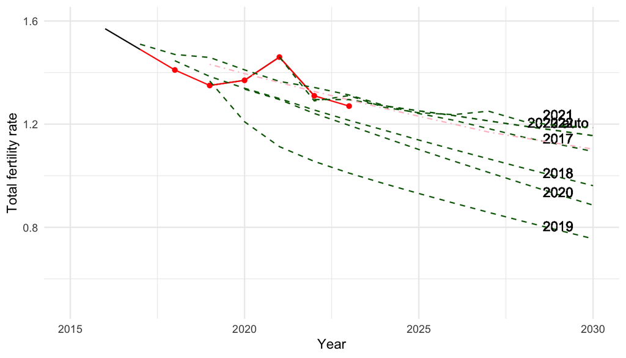

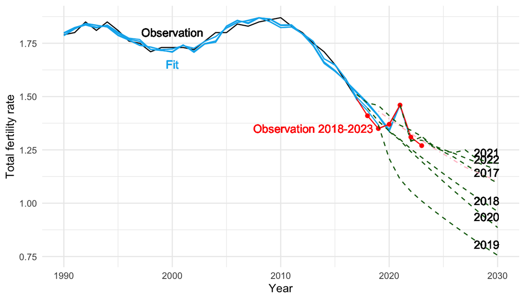

## Vanha ennuste uudella datalla 2023

```
##  [1] 1.796437 1.819547 1.835250 1.821769 1.835740 1.802705 1.773966 1.767706
##  [9] 1.721356 1.717682 1.707775 1.742115 1.707030 1.746221 1.754349 1.830985
## [17] 1.858085 1.841783 1.868563 1.864969 1.836198 1.836692 1.793189 1.736826
## [25] 1.655118 1.617970 1.573409 1.522824 1.471922 1.411549 1.346258 1.458688
## [33] 1.295325 1.295143 1.271364 1.251499 1.233518 1.212708 1.192858 1.174359
## [41] 1.155480
```

```
##    vuosi hedelmallisyysluku_sovite_2022 tfr_tk hluku tfr_hav
## 1   1990                       1.796437    NaN  1.79      NA
## 2   1991                       1.819547    NaN  1.80      NA
## 3   1992                       1.835250    NaN  1.85      NA
## 4   1993                       1.821769    NaN  1.81      NA
## 5   1994                       1.835740    NaN  1.85      NA
## 6   1995                       1.802705    NaN  1.81      NA
## 7   1996                       1.773966    NaN  1.76      NA
## 8   1997                       1.767706    NaN  1.75      NA
## 9   1998                       1.721356    NaN  1.71      NA
## 10  1999                       1.717682    NaN  1.73      NA
## 11  2000                       1.707775    NaN  1.73      NA
## 12  2001                       1.742115    NaN  1.73      NA
## 13  2002                       1.707030    NaN  1.72      NA
## 14  2003                       1.746221    NaN  1.76      NA
```

[output cut: 111 more lines]

## Johtopäätökset

Ennustemallilla saatu tulos vastaa havaittua alenevaa syntyvyyskehitystä. Jos eri syntyvyyteen vaikuttavien tekijöiden kehitys jatkuu nykyisenkaltaisena, voi kokonaishedelmällisyysluvun ja syntyvyyden arvioida jatkavan alenevaa trendiään kohti kokonaishedelmällisyyslukua 1,1 vuoteen 2030 mennessä.

Sosiaalisen median päivittäinen käyttö alkaa olla saavuttanut maksimitason, eikä se voi enää kasva. Tämän tekijän kasvu tuskin enää jatkossa laskee syntyvyyttä yhtä voimakkaasti kuin viime vuosina, ellei sen vaikutus tule muuta kautta kuin päivittäisten käyttäjien osuutena.

Sitä vastoin sisäkaupungissa asuvien osuus jatkaa kasvuaan. Tämän lisäksi heidän hedelmällisyyslukunsa on laskenut [TK].

# Viittaukset

Becker, G.S., Barro, R.J., Reformulation of the economic theory of fertility, The quarterly journal of economics, 1988

Boldrin, M., De Nardi, M., Jones, L.E. Fertility and social security, Journal of Demographic Economics 81, 261-299, https://doi.org/10.1017/dem.2014.14, 2015

Doepke, M., Child mortality and fertility decline: Does the Barro-Becker model fit the facts?

Hiilamo, H. T., Fertility Response to Economic Recessions in Finland 1991–2015 Finnish Yearbook of Population Research 52, 15-28 . DOI: 10.23979/fypr.65254, 2017

Kohler, H.-P., Kohler, I., Fertility Decline in Russia in the Early and Mid 1990s: The Role of Economic Uncertainty and Labour Market Crises, European Journal of Population 18, 233-262, https://doi.org/10.1023/A:1019701812709, 2002.

Martine, G., Alves, J.E., Cavenaghi, S., Urbanization and fertility decline: Cashing in on structural change, IIED Working paper, 2013

Miettinen, A., Miksi syntyvyys laskee? Suomalaisten lastensaantiin liittyviä toiveita ja odotuksia. Perhebarometri 2015. Väestöliitto, 2015.

Miettinen, A., Jalovaara, M. Stable employment – more babies? Life stage and educational differences in the effects of labour market attachment on first birth among Finnish men and women. Working Papers on Social and Economic Issues 15/2016, Turku Center for Welfare Research, 2016

Rotkirch, A., Tammisalo, K., Miettinen, A., Berg, V. Miksi vanhemmuutta lykätään? Perhebarometri, 2017.

Tanskanen, A.J. Sosiaalisen median aktiivikäyttö ja syntyvyys. https://ajtanskanen.github.io/posts/2018/11/Sosiaalisen-median-aktiivik%C3%A4ytt%C3%B6-ja-syntyvyys/, 2018

Tikanmäki, H., Huomisen aikuiset syntyvät nyt, Eläketurvakeskuksen blogi https://www.etk.fi/blogit/huomisen-aikuiset-syntyvat-nyt/, 2017

# Liite: Aika-sarjojen kuvaukset

*syntyneet* Syntyneiden lasten lukumäärä. Lähde: Tilastokeskus

*hedelmallisyysluku* “Kokonaishedelmällisyysluku saadaan laskemalla yhteen yhdelle ikävuodelle lasketut hedelmällisyysluvut. Näin saatu luku tarkoittaa laskennallista lasten määrää, jonka nainen synnyttää kyseisen vuoden hedelmällisyyden pysyessä voimassa naisen koko hedelmällisen kauden edellyttäen, ettei hän kuole ennen tämän kauden päättymistä.” Lähde: Tilastokeskus, Väestörakenne-tilasto

*lapsikuolleisuus* Alle 1-vuotiaana kuolleiden osuus elävänä syntyneistä. Lähde: Human mortality database

*tyollisyysaste_miehet_15_24_lag1, tyollisyysaste_naiset_25_34_lag1, tyollisyysaste_miehet_35_44_lag1, tyollisyysaste_naiset_15_24_lag1, tyollisyysaste_miehet_25_34_lag1, tyollisyysaste_naiset_45_44_lag1* Yhden vuoden viivästetty 10-vuotisikäluokittainen työllisyysaste miehille ja naisille. Lähde: Tilastokeskus

*synnyttajien_keskiika* Laskettu synnyttäneiden äitien ikien keskiarvona. Lähde: Tilastokeskus

*avioituvuus_naiset_25_29, avioituvuus_naiset_30_34* Naisten solmittujen avioliittojen lukumäärä suhteessa samanikäisten naisten lukumäärään. Lähde: Tilastokeskus

*sisempikaupunki, ulompikaupunki, kehykaupunki* Sisempi kaupunkialue on kaupunkien tiivis yhtenäinen tehokkaasti rakennettu alue. Ulompi kaupunkialue on sisemmän kaupunkialueen reunasta yhtenäisesti jatkuvan taajamarakenteen reunalle ulottuva kaupunkimaisen tehokkuuden alue. Kaupungin kehysalue on kaupunkiin välittömästi kytkeytyvä osa kaupungin ja maaseudun välivyöhykkeestä. Lähde: TK/Ympäristöministeriö

*naisten_lkm_15_19, naisten_lkm_20_24, naisten_lkm_25_29, naisten_lkm_30_34,naisten_lkm_35_39, naisten_lkm_40_45, naisten_lkm_45_49* Synnytysikäiset naiset 5-vuotisikäluokittain Lähde: Tilastokeskus

*miesten_tyottomyysaste_15_24_lag1, naisten_tyottomyysaste_15_24_lag1, miesten_tyottomyysaste_25_34_lag1, naisten_tyottomyysaste_25_34_lag1, miesten_tyottomyysaste_35_44_lag1, naisten_tyottomyysaste_35_44_lag1* Yhden vuoden viivästetty 10-vuotisikäluokittainen työttömyysaste miehille ja naisille Lähde: Tilastokeskus

*some_25_34, some_35_44* “Seuraa jotain yhteisöpalvelua yleensä jatkuvasti kirjautuneena tai useasti päivässä”. Tilastokeskuksen Viestintä- ja tietotekniikan käyttö-tutkimuksesta 10-vuotisikäluokat. Aineisto 2012-2021. Tilastoa jatkettu taaksepäin suhteuttamalla 2012 tieto Internetin käyttäjien lukumäärän muutoksella Lähde: Tilastokeskus